[figure not shown]

# Mobile Phone Review Analysis

## Context

The product companies can utilize the detailed review comments to gather insights from the end user. Most of the products are sold via e-commerce sites like Flipkart or Amazon where customers can buy a product and give their review about the product on the web site. Product managers can identify the relevant reviews from the website and run a sentiment analysis tool to understand what the sentiments of the customer are. Based on their sentiments, they can identify what users think of the current product. Are they happy? Discontent? They can also come up with a document that lists the features, the team needs to focus on for making the product better.

## Objective

Given the review data rating label, we will try to get insights about various brands and their ratings using text analytics and build a model to predict the rating and overall sentiment.

### Data Dictionary

product_data.csv - contains product details

- 'asin', - Product ASIN
- 'brand', - Product Brand
- 'title', - Product Title
- 'url', - Product URL
- 'image', - Product Image URL
- 'rating',- Product Avg. Rating
- 'reviewUrl' - Product Review Page URL
- 'totalReviews' - Product Total Reviews
- ‘price’ - Product Price ($)
- ‘originalPrice’ - Product Original Price ($)

reviews.csv - contains user review details

- 'asin' - Product ASIN
- 'name' - Reviewer Name
- 'rating' - Reviewer Rating (scale 1 to 5)
- 'date' - Review Date
- 'verified' - Valid Customer
- 'title' - Review Title
- 'body' - Review Content
- 'helpfulVotes - Helpful Feedbacks

## Table of Content

1. Import Libraries
2. Setting options
3. Read Data
4. Data Analysis and EDA
5. Text preprocessing and Vectorization
6. Model building
7. Conclusion and Interpretation

## 1. Import Libraries

Let us start by mounting the drive

```python
from google.colab import drive
drive.mount('/content/drive')
```

Let us check for the version of installed tensorflow.

```python
# used to supress display of warnings
import warnings

# os is used to provide a way of using operating system dependent functionality
# We use it for setting working folder
import os

# Pandas is used for data manipulation and analysis
import pandas as pd

# Numpy is used for large, multi-dimensional arrays and matrices, along with mathematical operators on these arrays
import numpy as np

# Matplotlib is a data visualization library for 2D plots of arrays, built on NumPy arrays
# and designed to work with the broader SciPy stack
import matplotlib.pyplot as plt
%matplotlib inline
from matplotlib import pyplot

# Seaborn is based on matplotlib, which aids in drawing attractive and informative statistical graphics.
import seaborn as sns
import tensorflow
print(tensorflow.__version__)
```

```
2.4.1
```

## 2. Setting Options

```python
# suppress display of warnings
warnings.filterwarnings('ignore')

# display all dataframe columns
pd.options.display.max_columns = None

# to set the limit to 3 decimals
pd.options.display.float_format = '{:.7f}'.format

# display all dataframe rows
pd.options.display.max_rows = None
```

## 3. Read Data

### 3.1 Read the provided CSVs and check 5 random samples and shape to understand the datasets

```python
product_df = pd.read_csv("/content/drive/MyDrive/dataset/NLP internal Lab/product_data.csv")
product_df.head(10)
```

|  | asin | brand | title | url | image | rating | reviewUrl | totalReviews | price | originalPrice |
| --- | --- | --- | --- | --- | --- | --- | --- | --- | --- | --- |
| 0 | B0000SX2UC | NaN | Dual-Band / Tri-Mode Sprint PCS Phone w/ Voice... | https://www.amazon.com/Dual-Band-Tri-Mode-Acti... | https://m.media-amazon.com/images/I/2143EBQ210... | 3.0000000 | https://www.amazon.com/product-reviews/B0000SX2UC | 14 | 0.0000000 | 0.0000000 |
| 1 | B0009N5L7K | Motorola | Motorola I265 phone | https://www.amazon.com/Motorola-i265-I265-phon... | https://m.media-amazon.com/images/I/419WBAVDAR... | 3.0000000 | https://www.amazon.com/product-reviews/B0009N5L7K | 7 | 49.9500000 | 0.0000000 |
| 2 | B000SKTZ0S | Motorola | MOTOROLA C168i AT&T CINGULAR PREPAID GOPHONE C... | https://www.amazon.com/MOTOROLA-C168i-CINGULAR... | https://m.media-amazon.com/images/I/71b+q3ydkI... | 2.7000000 | https://www.amazon.com/product-reviews/B000SKTZ0S | 22 | 99.9900000 | 0.0000000 |
| 3 | B001AO4OUC | Motorola | Motorola i335 Cell Phone Boost Mobile | https://www.amazon.com/Motorola-i335-Phone-Boo... | https://m.media-amazon.com/images/I/710UO8gdT+... | 3.3000000 | https://www.amazon.com/product-reviews/B001AO4OUC | 21 | 0.0000000 | 0.0000000 |
| 4 | B001DCJAJG | Motorola | Motorola V365 no contract cellular phone AT&T | https://www.amazon.com/Motorola-V365-contract-... | https://m.media-amazon.com/images/I/61LYNCVrrK... | 3.1000000 | https://www.amazon.com/product-reviews/B001DCJAJG | 12 | 149.9900000 | 0.0000000 |
| 5 | B001GQ3DJM | Nokia | Nokia 1680 Black Phone (T-Mobile) | https://www.amazon.com/Nokia-1680-Black-Phone-... | https://m.media-amazon.com/images/I/41X4VeqkFO... | 2.7000000 | https://www.amazon.com/product-reviews/B001GQ3DJM | 3 | 0.0000000 | 0.0000000 |
| 6 | B0029F2O3A | Samsung | Samsung Alias2 U750 Phone, Black (Verizon Wire... | https://www.amazon.com/Samsung-Alias2-Phone-Ve... | https://m.media-amazon.com/images/I/41HWHpfPlM... | 3.0000000 | https://www.amazon.com/product-reviews/B0029F2O3A | 29 | 0.0000000 | 0.0000000 |
| 7 | B002AS9WEA | Samsung | Samsung a167 Prepaid GoPhone (AT&T) | https://www.amazon.com/Samsung-a167-Prepaid-Go... | https://m.media-amazon.com/images/I/61OXcZ-oef... | 2.9000000 | https://www.amazon.com/product-reviews/B002AS9WEA | 18 | 0.0000000 | 0.0000000 |
| 8 | B002UHS0UI | Motorola | Verizon Wireless Motorola RAZR V3m - Silver | https://www.amazon.com/Verizon-Wireless-Motoro... | https://m.media-amazon.com/images/I/61pVtPaTkM... | 2.7000000 | https://www.amazon.com/product-reviews/B002UHS0UI | 208 | 0.0000000 | 0.0000000 |
| 9 | B002WTC1NG | Motorola | Motorola Barrage V860 Phone (Verizon Wireless) | https://www.amazon.com/Motorola-Barrage-V860-V... | https://m.media-amazon.com/images/I/81k6Nq0KI1... | 3.6000000 | https://www.amazon.com/product-reviews/B002WTC1NG | 352 | 139.9900000 | 0.0000000 |

```python
review_df = pd.read_csv("/content/drive/MyDrive/dataset/NLP internal Lab/reviews.csv")
review_df.head(10)
```

|  | asin | name | rating | date | verified | title | body | helpfulVotes |
| --- | --- | --- | --- | --- | --- | --- | --- | --- |
| 0 | B0000SX2UC | Janet | 3 | October 11, 2005 | False | Def not best, but not worst | I had the Samsung A600 for awhile which is abs... | 1.0000000 |
| 1 | B0000SX2UC | Luke Wyatt | 1 | January 7, 2004 | False | Text Messaging Doesn't Work | Due to a software issue between Nokia and Spri... | 17.0000000 |
| 2 | B0000SX2UC | Brooke | 5 | December 30, 2003 | False | Love This Phone | This is a great, reliable phone. I also purcha... | 5.0000000 |
| 3 | B0000SX2UC | amy m. teague | 3 | March 18, 2004 | False | Love the Phone, BUT...! | I love the phone and all, because I really did... | 1.0000000 |
| 4 | B0000SX2UC | tristazbimmer | 4 | August 28, 2005 | False | Great phone service and options, lousy case! | The phone has been great for every purpose it ... | 1.0000000 |
| 5 | B0000SX2UC | J. White | 4 | September 25, 2005 | False | Worked great for me | Hello, I have this phone and used it until I d... | nan |
| 6 | B0000SX2UC | the cell phone store owner | 5 | April 16, 2004 | False | Wanna cool Nokia? You have it here! | Cool. Cheap. Color: 3 words that describe the ... | 2.0000000 |
| 7 | B0000SX2UC | Matt | 4 | April 3, 2004 | False | Problem with 3588i universal headset | The 3599i is overall a nice phone, except that... | 2.0000000 |
| 8 | B0000SX2UC | Charles Cook | 5 | November 24, 2003 | False | cool phone!!!!!!!! | I've never owned a Nokia phone before, so this... | 7.0000000 |
| 9 | B0000SX2UC | Amazon Customer | 3 | February 2, 2004 | False | Pissed off-a little bit | ok well im in school and i need the text messa... | 3.0000000 |

## 4. Data Analysis and EDA

### 4.1 Drop unnecessary columns like 'url', 'image' from the product_data

```python
product_df.drop("url" ,axis =1,inplace=True)
product_df.drop("image" ,axis =1,inplace=True)
```

### 4.2 Check statistical summary of both datasets. Note:- Include both numerical and object type columns.

```python
product_df.describe(include= 'all')
```

|  | asin | brand | title | rating | reviewUrl | totalReviews | price | originalPrice |
| --- | --- | --- | --- | --- | --- | --- | --- | --- |
| count | 720 | 716 | 720 | 720.0000000 | 720 | 720.0000000 | 720.0000000 | 720.0000000 |
| unique | 720 | 10 | 718 | nan | 720 | nan | nan | nan |
| top | B07MZ2TRTC | Samsung | Apple iPhone 6S, 64GB, Rose Gold - For AT&T / ... | nan | https://www.amazon.com/product-reviews/B072QR6NKG | nan | nan | nan |
| freq | 1 | 346 | 2 | nan | 1 | nan | nan | nan |
| mean | NaN | NaN | NaN | 3.7137500 | NaN | 105.6791667 | 234.9489306 | 63.6907778 |
| std | NaN | NaN | NaN | 0.7160138 | NaN | 167.6011014 | 200.0084407 | 172.4053696 |
| min | NaN | NaN | NaN | 1.0000000 | NaN | 1.0000000 | 0.0000000 | 0.0000000 |
| 25% | NaN | NaN | NaN | 3.3000000 | NaN | 7.0000000 | 97.5125000 | 0.0000000 |
| 50% | NaN | NaN | NaN | 3.8000000 | NaN | 32.0000000 | 188.9750000 | 0.0000000 |
| 75% | NaN | NaN | NaN | 4.1000000 | NaN | 122.2500000 | 336.7250000 | 0.0000000 |
| max | NaN | NaN | NaN | 5.0000000 | NaN | 983.0000000 | 999.9900000 | 999.9900000 |

```python
review_df.describe(include= 'all')
```

|  | asin | name | rating | date | verified | title | body | helpfulVotes |
| --- | --- | --- | --- | --- | --- | --- | --- | --- |
| count | 67986 | 67984 | 67986.0000000 | 67986 | 67986 | 67972 | 67965 | 27215.0000000 |
| unique | 720 | 47323 | nan | 2983 | 2 | 41489 | 59811 | nan |
| top | B00F2SKPIM | Amazon Customer | nan | December 11, 2019 | True | Five Stars | Good | nan |
| freq | 981 | 6507 | nan | 234 | 61225 | 6043 | 303 | nan |
| mean | NaN | NaN | 3.8079163 | NaN | NaN | NaN | NaN | 8.2296895 |
| std | NaN | NaN | 1.5829058 | NaN | NaN | NaN | NaN | 31.9548772 |
| min | NaN | NaN | 1.0000000 | NaN | NaN | NaN | NaN | 1.0000000 |
| 25% | NaN | NaN | 3.0000000 | NaN | NaN | NaN | NaN | 1.0000000 |
| 50% | NaN | NaN | 5.0000000 | NaN | NaN | NaN | NaN | 2.0000000 |
| 75% | NaN | NaN | 5.0000000 | NaN | NaN | NaN | NaN | 5.0000000 |
| max | NaN | NaN | 5.0000000 | NaN | NaN | NaN | NaN | 990.0000000 |

```python
product_df.describe(include='O')
```

|  | asin | brand | title | reviewUrl |
| --- | --- | --- | --- | --- |
| count | 720 | 716 | 720 | 720 |
| unique | 720 | 10 | 718 | 720 |
| top | B07MZ2TRTC | Samsung | Apple iPhone 6S, 64GB, Rose Gold - For AT&T / ... | https://www.amazon.com/product-reviews/B072QR6NKG |
| freq | 1 | 346 | 2 | 1 |

```python
review_df.describe(include='O')
```

|  | asin | name | date | title | body |
| --- | --- | --- | --- | --- | --- |
| count | 67986 | 67984 | 67986 | 67972 | 67965 |
| unique | 720 | 47323 | 2983 | 41489 | 59811 |
| top | B00F2SKPIM | Amazon Customer | December 11, 2019 | Five Stars | Good |
| freq | 981 | 6507 | 234 | 6043 | 303 |

```python
review_df.describe()
```

|  | rating | helpfulVotes |
| --- | --- | --- |
| count | 67986.0000000 | 27215.0000000 |
| mean | 3.8079163 | 8.2296895 |
| std | 1.5829058 | 31.9548772 |
| min | 1.0000000 | 1.0000000 |
| 25% | 3.0000000 | 1.0000000 |
| 50% | 5.0000000 | 2.0000000 |
| 75% | 5.0000000 | 5.0000000 |
| max | 5.0000000 | 990.0000000 |

```python
product_df.describe()
```

|  | rating | totalReviews | price | originalPrice |
| --- | --- | --- | --- | --- |
| count | 720.0000000 | 720.0000000 | 720.0000000 | 720.0000000 |
| mean | 3.7137500 | 105.6791667 | 234.9489306 | 63.6907778 |
| std | 0.7160138 | 167.6011014 | 200.0084407 | 172.4053696 |
| min | 1.0000000 | 1.0000000 | 0.0000000 | 0.0000000 |
| 25% | 3.3000000 | 7.0000000 | 97.5125000 | 0.0000000 |
| 50% | 3.8000000 | 32.0000000 | 188.9750000 | 0.0000000 |
| 75% | 4.1000000 | 122.2500000 | 336.7250000 | 0.0000000 |
| max | 5.0000000 | 983.0000000 | 999.9900000 | 999.9900000 |

### 4.3 From the above statistical summary, write inferences like count of unique products, top brand, top title, range of rating, price range, etc

```python
Top brand is Samsung
Unique products are 720 in both csvs
Rating ranges from 1-5
Price ranges from 0-999 , Zero could be invalid value
```

### 4.4 Analyze the distribution of ratings and other categorical features like brand, etc

```python
product_df['rating'].value_counts()
```

```
4.1000000    59
3.8000000    55
4.0000000    52
3.9000000    47
3.7000000    46
3.5000000    43
3.6000000    40
3.2000000    37
3.3000000    34
5.0000000    34
4.4000000    32
4.2000000    31
4.5000000    31
4.3000000    28
3.1000000    21
3.4000000    21
3.0000000    20
2.9000000    16
1.0000000    16
2.8000000    10
4.6000000    10
2.7000000     8
2.5000000     6
4.7000000     5
2.4000000     4
2.6000000     4
2.1000000     3
2.0000000     2
1.4000000     1
2.3000000     1
2.2000000     1
1.5000000     1
4.8000000     1
Name: rating, dtype: int64
```

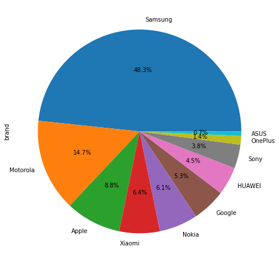

```python
product_df['brand'].value_counts().plot(kind = 'pie', autopct='%1.1f%%', figsize=(10,8))
```

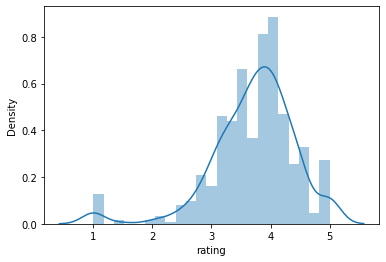

```python
sns.distplot(product_df['rating'])
```

### 4.5 Display average rating per brand

```python
product_df.groupby(['brand']).mean()['rating'].sort_values(ascending=False)
```

```
brand
Xiaomi     4.4152174
HUAWEI     4.0218750
ASUS       3.8600000
Sony       3.7888889
Apple      3.7825397
Google     3.7710526
Motorola   3.6438095
Samsung    3.6326590
OnePlus    3.5800000
Nokia      3.3863636
Name: rating, dtype: float64
```

```python
product_df.groupby(['brand']).count()['totalReviews'].sort_values(ascending=False)
```

```
brand
Samsung     346
Motorola    105
Apple        63
Xiaomi       46
Nokia        44
Google       38
HUAWEI       32
Sony         27
OnePlus      10
ASUS          5
Name: totalReviews, dtype: int64
```

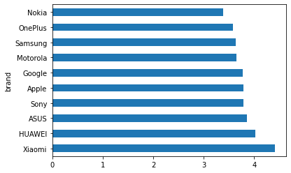

```python
product_df.groupby(['brand']).mean()['rating'].sort_values(ascending=False).plot(kind = 'barh')
```

### 4.6 Display average price per brand

```python
product_df.groupby(['brand']).mean()['price'].sort_values(ascending=False)
```

```
brand
OnePlus    426.1960000
Sony       332.7248148
ASUS       309.6860000
Apple      303.5811111
Samsung    256.5272543
Google     241.8676316
HUAWEI     218.8290625
Xiaomi     214.9676087
Motorola   139.1210476
Nokia      111.4438636
Name: price, dtype: float64
```

### 4.7 Display average 'totalReviews' per brand

```python
product_df.groupby(['brand']).mean()['totalReviews'].sort_values(ascending=False)
```

```
brand
Nokia      140.5000000
Sony       122.6666667
Xiaomi     121.1739130
Google     111.5263158
Samsung    108.9624277
Apple      100.2380952
Motorola    89.7047619
HUAWEI      77.0937500
ASUS        52.6000000
OnePlus     40.6000000
Name: totalReviews, dtype: float64
```

one plus has the highest avg price there are some phones having price as zero . Imputing such values may change the mean price as well

### 4.8 Merge two datasets using 'asin' and check the shape of the final dataset

```python
df  = pd.merge(review_df,product_df, how = 'left', left_on = 'asin', right_on='asin')
df.shape
```

```
(67986, 15)
```

### 4.9 Rename important features with appropriate names.

Imortant features - "rating_x": "user_rating", "title_x": "review_title", "title_y": "item_title", "rating_y": "overall_rating"

```python
df.rename(columns={"rating_x": "user_rating", "title_x": "review_title", "title_y": "item_title", "rating_y": "overall_rating"}, inplace= True)
```

```python
df.head()
```

|  | asin | name | user_rating | date | verified | review_title | body | helpfulVotes | brand | item_title | overall_rating | reviewUrl | totalReviews | price | originalPrice |
| --- | --- | --- | --- | --- | --- | --- | --- | --- | --- | --- | --- | --- | --- | --- | --- |
| 0 | B0000SX2UC | Janet | 3 | October 11, 2005 | False | Def not best, but not worst | I had the Samsung A600 for awhile which is abs... | 1.0000000 | NaN | Dual-Band / Tri-Mode Sprint PCS Phone w/ Voice... | 3.0000000 | https://www.amazon.com/product-reviews/B0000SX2UC | 14 | 0.0000000 | 0.0000000 |
| 1 | B0000SX2UC | Luke Wyatt | 1 | January 7, 2004 | False | Text Messaging Doesn't Work | Due to a software issue between Nokia and Spri... | 17.0000000 | NaN | Dual-Band / Tri-Mode Sprint PCS Phone w/ Voice... | 3.0000000 | https://www.amazon.com/product-reviews/B0000SX2UC | 14 | 0.0000000 | 0.0000000 |
| 2 | B0000SX2UC | Brooke | 5 | December 30, 2003 | False | Love This Phone | This is a great, reliable phone. I also purcha... | 5.0000000 | NaN | Dual-Band / Tri-Mode Sprint PCS Phone w/ Voice... | 3.0000000 | https://www.amazon.com/product-reviews/B0000SX2UC | 14 | 0.0000000 | 0.0000000 |
| 3 | B0000SX2UC | amy m. teague | 3 | March 18, 2004 | False | Love the Phone, BUT...! | I love the phone and all, because I really did... | 1.0000000 | NaN | Dual-Band / Tri-Mode Sprint PCS Phone w/ Voice... | 3.0000000 | https://www.amazon.com/product-reviews/B0000SX2UC | 14 | 0.0000000 | 0.0000000 |
| 4 | B0000SX2UC | tristazbimmer | 4 | August 28, 2005 | False | Great phone service and options, lousy case! | The phone has been great for every purpose it ... | 1.0000000 | NaN | Dual-Band / Tri-Mode Sprint PCS Phone w/ Voice... | 3.0000000 | https://www.amazon.com/product-reviews/B0000SX2UC | 14 | 0.0000000 | 0.0000000 |

### 4.10 Select rows having verified reviews and check the shape of the final dataset

```python
dff = df[df['verified'] == True]
dff.shape
```

```
(61225, 15)
```

### 4.11 Check the number of reviews for various brands and report the brand that have highest number of reviews

```python
dff['brand'].value_counts()
```

```
Samsung     31020
Motorola     7714
Nokia        4878
Apple        4876
Xiaomi       4207
Google       3163
Sony         2691
HUAWEI       2019
OnePlus       304
ASUS          206
Name: brand, dtype: int64
```

### 4.12 Drop irrelevant columns and keep important features like 'brand','body','price','user_rating','review_title' for further analysis

```python
df_final = dff[['brand','body', 'price', 'user_rating', 'review_title']]
```

```python
df_final.head()
```

|  | brand | body | price | user_rating | review_title |
| --- | --- | --- | --- | --- | --- |
| 14 | Motorola | DON'T BUY OUT OF SERVICE | 49.9500000 | 1 | Stupid phone |
| 17 | Motorola | 1 star because the phones locked so I have to ... | 49.9500000 | 1 | Phones locked |
| 18 | Motorola | The product has been very good. I had used thi... | 49.9500000 | 5 | Excellent product |
| 21 | Motorola | I bought this phone to replace an LG phone tha... | 99.9900000 | 4 | Nice, but |
| 22 | Motorola | I purchased this phone for my AT&T phone repla... | 99.9900000 | 1 | It seems it doesn't work with the existing AT&... |

```python
df_final.isna().sum()
```

```
brand           147
body             18
price             0
user_rating       0
review_title     14
dtype: int64
```

```python
df_final.dropna(inplace=True)
df_final.shape
```

```
(61051, 5)
```

```python
df_final.isna().sum().sum()
```

```
0
```

### 4.13 Perform univariate analysis. Check distribution of price, user_rating

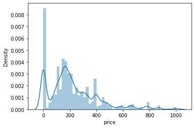

```python
sns.distplot(df_final['price'])
```

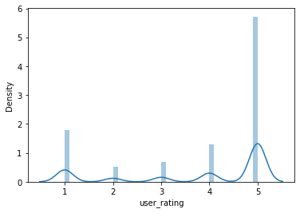

```python
sns.distplot(df_final['user_rating'])
```

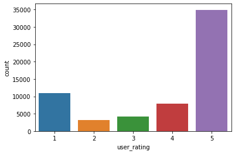

```python
sns.countplot(df_final['user_rating'])
```

### 4.14 Create a new column called "sentiment". It should have value as 1 (positive) if the user_Rating is greater than 3, value as 0 (neutral) if the user_Rating == 3, and -1 (negative) is the user_Rating is less than 3.

```python
df_final["sentiment"] = df_final["user_rating"].apply(lambda x: 1 if x>3 else(0 if x==3 else -1))
```

### 4.15 Check frequency distribution of the 'sentiment'

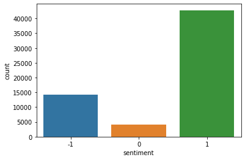

```python
sns.countplot(df_final['sentiment'])
```

### 4.16 Perform bivariate analysis. Check correlation/crosstab between features and write your inferences.

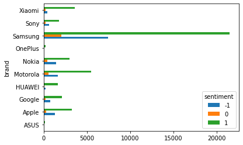

```python
pd.crosstab(df_final['brand'], df_final['sentiment']).plot(kind='barh')
```

```python
pd.crosstab(df_final['brand'], df_final['sentiment'], normalize=True)
```

| sentiment brand | -1 | 0 | 1 |
| --- | --- | --- | --- |
| ASUS | 0.0008026 | 0.0003276 | 0.0022440 |
| Apple | 0.0216213 | 0.0050286 | 0.0532014 |
| Google | 0.0131529 | 0.0033906 | 0.0352492 |
| HUAWEI | 0.0042751 | 0.0017199 | 0.0270757 |
| Motorola | 0.0273050 | 0.0090580 | 0.0899740 |
| Nokia | 0.0235377 | 0.0076493 | 0.0486970 |
| OnePlus | 0.0005569 | 0.0001802 | 0.0042424 |
| Samsung | 0.1222421 | 0.0332509 | 0.3522301 |
| Sony | 0.0108598 | 0.0035380 | 0.0296801 |
| Xiaomi | 0.0069942 | 0.0032923 | 0.0586231 |

## 5. Text Preprocessing and Vectorization

We will analyze the 'body' and 'review_title' to gain more understanding.

We will ppeform the below tasks

### 5.1 Change the datatype of the 'body' column to 'str' and convert it into lowercase. Print any two samples and check the output.

```python
df_final.head()
```

|  | brand | body | price | user_rating | review_title | sentiment |
| --- | --- | --- | --- | --- | --- | --- |
| 14 | Motorola | DON'T BUY OUT OF SERVICE | 49.9500000 | 1 | Stupid phone | -1 |
| 17 | Motorola | 1 star because the phones locked so I have to ... | 49.9500000 | 1 | Phones locked | -1 |
| 18 | Motorola | The product has been very good. I had used thi... | 49.9500000 | 5 | Excellent product | 1 |
| 21 | Motorola | I bought this phone to replace an LG phone tha... | 99.9900000 | 4 | Nice, but | 1 |
| 22 | Motorola | I purchased this phone for my AT&T phone repla... | 99.9900000 | 1 | It seems it doesn't work with the existing AT&... | -1 |

```python
df_final["body"] = df_final["body"].astype("str")
```

```python
df_final["body"] = df_final["body"].apply(lambda x: x.lower())
```

```python
df_final['body'].head(5)
```

```
14                             don't buy out of service
17    1 star because the phones locked so i have to ...
18    the product has been very good. i had used thi...
21    i bought this phone to replace an lg phone tha...
22    i purchased this phone for my at&t phone repla...
Name: body, dtype: object
```

### 5.2 Remove punctuations from the lowercased 'body' column and display at least two samples.

```python
df_final['keywords'] = df_final['body'].str.replace('[^\w\s]','') #[',', '*', '=', ',']
```

```python
import string
punc = set(string.punctuation)
```

```python
df_final['keywords'].head(5)
```

```
14                              dont buy out of service
17    1 star because the phones locked so i have to ...
18    the product has been very good i had used this...
21    i bought this phone to replace an lg phone tha...
22    i purchased this phone for my att phone replac...
Name: keywords, dtype: object
```

### 5.3 Remove stop words from the above pre-processed 'body' column and display at least two samples.

```python
import nltk
nltk.download('stopwords')
```

```
True
```

```python
from nltk.corpus import stopwords
stop = set(stopwords.words('english'))
```

```python
df_final['keywords'] = df_final['keywords'].apply(lambda x: ' '.join(i for i in x.split() if i not in stop))
```

```python
df_final['keywords'].head()
```

```
14                                     dont buy service
17      1 star phones locked pay additional fees unlock
18    product good used cell phone one projects work...
21    bought phone replace lg phone didnt like expec...
22    purchased phone att phone replacement even tho...
Name: keywords, dtype: object
```

### 5.4 Apply lemmatisation on the above preprocessed text and display a few samples

```python
import nltk
nltk.download('wordnet')
lemmatizer = nltk.stem.WordNetLemmatizer()
```

```python
tokennizer = nltk.tokenize.WhitespaceTokenizer()
```

```python
def lemmatizer_text(text):
  return [lemmatizer.lemmatize(i) for i in tokennizer.tokenize(text)]
```

```python
df_final['lem'] = df_final['keywords'].apply(lemmatizer_text)
df_final['lem'].head()
```

```
14                                 [dont, buy, service]
17    [1, star, phone, locked, pay, additional, fee,...
18    [product, good, used, cell, phone, one, projec...
21    [bought, phone, replace, lg, phone, didnt, lik...
22    [purchased, phone, att, phone, replacement, ev...
Name: lem, dtype: object
```

```python
df_final.head()
```

|  | brand | body | price | user_rating | review_title | sentiment | keywords | lem |
| --- | --- | --- | --- | --- | --- | --- | --- | --- |
| 14 | Motorola | don't buy out of service | 49.9500000 | 1 | Stupid phone | -1 | dont buy service | [dont, buy, service] |
| 17 | Motorola | 1 star because the phones locked so i have to ... | 49.9500000 | 1 | Phones locked | -1 | 1 star phones locked pay additional fees unlock | [1, star, phone, locked, pay, additional, fee,... |
| 18 | Motorola | the product has been very good. i had used thi... | 49.9500000 | 5 | Excellent product | 1 | product good used cell phone one projects work... | [product, good, used, cell, phone, one, projec... |
| 21 | Motorola | i bought this phone to replace an lg phone tha... | 99.9900000 | 4 | Nice, but | 1 | bought phone replace lg phone didnt like expec... | [bought, phone, replace, lg, phone, didnt, lik... |
| 22 | Motorola | i purchased this phone for my at&t phone repla... | 99.9900000 | 1 | It seems it doesn't work with the existing AT&... | -1 | purchased phone att phone replacement even tho... | [purchased, phone, att, phone, replacement, ev... |

### 5.5 Write a function to check word frequency of the text

```python
text = "dont buy service"
words = text.split()
words
```

```
['dont', 'buy', 'service']
```

```python
for i in words:
  print(words.count(i))
```

```
1
1
1
```

```python
def word_freq(text):
  words =text.split()
  freq = {word:words.count(word) for word in words}
  return freq
```

### 5.6 Check word frequency of review having top ratings (sentiment = 1) and display output of few samples

```python
df_positive = df_final[df_final['sentiment'] == 1 ]
```

```python
df_positive['keywords'].apply(word_freq)
```

```
18       {'product': 1, 'good': 1, 'used': 1, 'cell': 1...
21       {'bought': 1, 'phone': 4, 'replace': 1, 'lg': ...
24         {'served': 1, 'well': 1, 'back': 1, 'phone': 1}
26       {'sturdy': 1, 'clarity': 1, 'great': 1, 'easy'...
28       {'beautiful': 1, 'job': 1, 'used': 1, 'item': ...
43       {'phone': 6, 'isnt': 1, 'kidding': 1, 'says': ...
45        {'wont': 1, 'enter': 1, 'special': 1, 'code': 1}
46       {'mother': 3, 'said': 1, 'loves': 2, 'walkie':...
48       {'price': 1, 'really': 1, 'get': 1, 'solid': 1...
49       {'phone': 3, 'come': 1, 'sim': 2, 'cardinforma...
51       {'good': 1, 'phone': 1, 'works': 2, 'well': 1,...
52       {'get': 1, 'basic': 1, 'functions': 1, 'cell':...
64       {'replacement': 1, 'one': 1, 'mom': 1, 'went':...
65       {'shipping': 1, 'time': 1, 'phone': 5, 'great'...
67                         {'delivered': 1, 'promised': 1}
```

[output cut: 42796 more lines]

```python
word_frequency = df_final['review_title'].apply(word_freq)
word_frequency.head(10)
```

```
14                            {'Stupid': 1, 'phone': 1}
17                           {'Phones': 1, 'locked': 1}
18                       {'Excellent': 1, 'product': 1}
21                               {'Nice,': 1, 'but': 1}
22    {'It': 1, 'seems': 1, 'it': 1, 'doesn't': 1, '...
23                 {'Supply': 1, 'are': 1, 'needed': 1}
24                              {'Five': 1, 'Stars': 1}
25                      {'does': 1, 'the': 1, 'job': 1}
26        {'Awesome': 1, 'with': 1, 'a': 1, 'But!!': 1}
27                                {'One': 1, 'Star': 1}
Name: review_title, dtype: object
```

```python
word_frequency = df_final['keywords'].apply(word_freq)
word_frequency.head(10)
```

```
14                  {'dont': 1, 'buy': 1, 'service': 1}
17    {'1': 1, 'star': 1, 'phones': 1, 'locked': 1, ...
18    {'product': 1, 'good': 1, 'used': 1, 'cell': 1...
21    {'bought': 1, 'phone': 4, 'replace': 1, 'lg': ...
22    {'purchased': 1, 'phone': 4, 'att': 2, 'replac...
23    {'phone': 1, 'come': 1, 'charger': 1, 'didnt':...
24      {'served': 1, 'well': 1, 'back': 1, 'phone': 1}
25    {'got': 1, 'phone': 3, 'secondary': 1, 'cell':...
26    {'sturdy': 1, 'clarity': 1, 'great': 1, 'easy'...
27              {'phone': 1, 'stoped': 1, 'working': 1}
Name: keywords, dtype: object
```

### 5.7 Initialize tf-idf vectorizer and transform the preprocessed body text

```python
from sklearn.feature_extraction.text import TfidfVectorizer
tfidf = TfidfVectorizer()
```

```python
tfidf_data  = tfidf.fit_transform(df_final['keywords'])
```

```python
tfidf_data
```

```
<61051x38256 sparse matrix of type '<class 'numpy.float64'>'
	with 1185044 stored elements in Compressed Sparse Row format>
```

### 5.8 Segregate the data into dependent (sentiment) and independent (transformed body using tf-idf) features for building a classifier.

```python
y = df_final['sentiment']
```

### 5.9 Split the data into Train & Test Sets

```python
from sklearn.model_selection import train_test_split
X_train, X_test, y_train, y_test = train_test_split(tfidf_data, y, random_state=42, stratify = y, test_size=0.3)
```

```python
X_train.shape
```

```
(42735, 38256)
```

```python
y_train.shape
```

```
(42735,)
```

## 6. Model building

### 6.1 Build a random forest classifier to predict the 'sentiment'

### 6.2 Predict on test set

### 6.3 Check accuracy and confusion matrix

```python
from sklearn.ensemble import RandomForestClassifier
rf = RandomForestClassifier()
rf.fit(X_train, y_train)
```

```
RandomForestClassifier(bootstrap=True, ccp_alpha=0.0, class_weight=None,
                       criterion='gini', max_depth=None, max_features='auto',
                       max_leaf_nodes=None, max_samples=None,
                       min_impurity_decrease=0.0, min_impurity_split=None,
                       min_samples_leaf=1, min_samples_split=2,
                       min_weight_fraction_leaf=0.0, n_estimators=100,
                       n_jobs=None, oob_score=False, random_state=None,
                       verbose=0, warm_start=False)
```

```python
rf.score(X_train, y_train)
```

```
0.9957645957645958
```

```python
rf.score(X_test, y_test)
```

```
0.8543350076435903
```

```python
from sklearn.metrics import confusion_matrix
y_pred = rf.predict(X_test)
confusion_matrix(y_test, y_pred)
```

```
array([[ 3078,    12,  1147],
       [  362,    73,   800],
       [  342,     5, 12497]])
```

## 7. Write your conclusion

```python
Model is over fit, so we can optimize with hyper paramter tuning
Since comments are very long so features got increased the computation is very high
recall for particular class is comparing to other classes
```